# Reproducible Research: Peer Assessment 1

## Loading and preprocessing the data

```r
act<-read.csv("activity.csv")
```

## What is mean total number of steps taken per day?

The total number of steps per day is

```r
stepsDay<-aggregate(act[,1],list(act$date),sum,na.rm=TRUE)
stepsDay
```

```
##       Group.1     x
## 1  2012-10-01     0
## 2  2012-10-02   126
## 3  2012-10-03 11352
## 4  2012-10-04 12116
## 5  2012-10-05 13294
## 6  2012-10-06 15420
## 7  2012-10-07 11015
## 8  2012-10-08     0
## 9  2012-10-09 12811
## 10 2012-10-10  9900
## 11 2012-10-11 10304
## 12 2012-10-12 17382
## 13 2012-10-13 12426
## 14 2012-10-14 15098
```

[output cut: 47 more lines]

Histogram

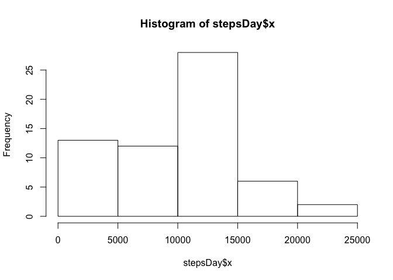

```r
hist(stepsDay$x)
```

The mean and median per day

```r
library(plyr)
stats<-ddply(act,~date,summarise,mean=mean(steps,na.rm=TRUE),median=median(steps,na.rm=TRUE))
stats
```

```
##          date       mean median
## 1  2012-10-01        NaN     NA
## 2  2012-10-02  0.4375000      0
## 3  2012-10-03 39.4166667      0
## 4  2012-10-04 42.0694444      0
## 5  2012-10-05 46.1597222      0
## 6  2012-10-06 53.5416667      0
## 7  2012-10-07 38.2465278      0
## 8  2012-10-08        NaN     NA
## 9  2012-10-09 44.4826389      0
## 10 2012-10-10 34.3750000      0
## 11 2012-10-11 35.7777778      0
## 12 2012-10-12 60.3541667      0
## 13 2012-10-13 43.1458333      0
## 14 2012-10-14 52.4236111      0
```

[output cut: 47 more lines]

## What is the average daily activity pattern?

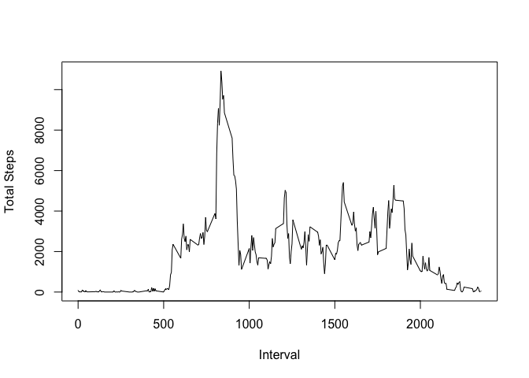

```r
stepsInt<-aggregate(act[,1],list(act$interval),sum,na.rm=TRUE)
plot(stepsInt$Group.1,stepsInt$x,type="l",xlab="Interval",ylab="Total Steps")
```

```r
maxStInt<-stepsInt[stepsInt$x==max(stepsInt$x),1]
```

The 5-minute interval that contains the maximum number of steps is 835

## Imputing missing values

```r
missVal<-sum(is.na(act$steps))
```

The total number of missing values is 2304.

A new data set will contain the same data with NAs values changed by the media in the interval

```r
stepsIntMean<-aggregate(act[,1],list(act$interval),mean,na.rm=TRUE)
act2<-act
for (i in 1:length(act$steps)){
        if (is.na(act2[i,1])==TRUE){
                act2[i,1]<-stepsIntMean[stepsIntMean$Group.1==act2[i,3],2]
        }
}
```

Histogram of the new data set

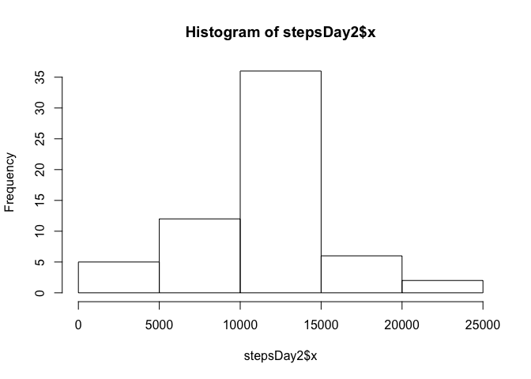

```r
stepsDay2<-aggregate(act2[,1],list(act2$date),sum,na.rm=TRUE)
hist(stepsDay2$x)
```

The mean and median per day

```r
stats2<-ddply(act2,~date,summarise,mean=mean(steps,na.rm=TRUE),median=median(steps,na.rm=TRUE))
stats2
```

```
##          date       mean   median
## 1  2012-10-01 37.3825996 34.11321
## 2  2012-10-02  0.4375000  0.00000
## 3  2012-10-03 39.4166667  0.00000
## 4  2012-10-04 42.0694444  0.00000
## 5  2012-10-05 46.1597222  0.00000
## 6  2012-10-06 53.5416667  0.00000
## 7  2012-10-07 38.2465278  0.00000
## 8  2012-10-08 37.3825996 34.11321
## 9  2012-10-09 44.4826389  0.00000
## 10 2012-10-10 34.3750000  0.00000
## 11 2012-10-11 35.7777778  0.00000
## 12 2012-10-12 60.3541667  0.00000
## 13 2012-10-13 43.1458333  0.00000
## 14 2012-10-14 52.4236111  0.00000
```

[output cut: 47 more lines]

The correlation plot between the mean of the two data sets (with and without NAs) shows that the results are similar

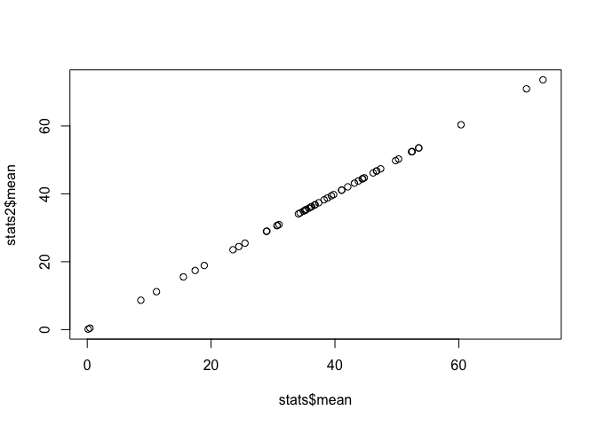

```r
plot(stats$mean,stats2$mean)
```

The values for the median are similar for the days in which there are not NAs (median=0) and differs in the days in which all steps were NA (median=34.11321)

## Are there differences in activity patterns between weekdays and weekends?

First create the data set with a new column

```r
act3<-act2
act3$Day<-weekdays(as.Date(act2$date))
act3[act3$Day=="domingo"|act3$Day=="sábado",]$Day<-"weekend"
act3[act3$Day=="lunes"|act3$Day=="martes"|act3$Day=="miércoles"|act3$Day=="jueves"|act3$Day=="viernes",]$Day<-"weekday"
act3$Day<-as.factor(act3$Day)
```

Create data sets for weekdays and weekends an plot the average of steps by interval

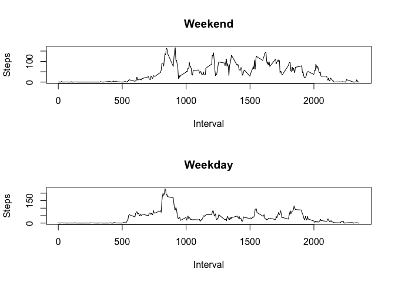

```r
Weekend<-act3[act3$Day=="weekend",]
Weekday<-act3[act3$Day=="weekday",]
stepsIntWD<-aggregate(Weekday[,1],list(Weekday$interval),mean)
stepsIntW<-aggregate(Weekend[,1],list(Weekend$interval),mean)
par(mfrow=(c(2,1)))
plot(stepsIntW$Group.1,stepsIntW$x,type="l",main="Weekend",ylab="Steps",xlab="Interval")
plot(stepsIntWD$Group.1,stepsIntWD$x,type="l",main="Weekday",ylab="Steps",xlab="Interval")
```